# Applied Data Science (Prof. Dr. Kauffeldt)

## Inhalt

- 1 Deskriptive Methoden
- 2 Testmethoden
  - 2.1 Ablauf statistischer Test
  - 2.2 Testen von Lageparametern
  - 2.3 Testen von Zusammenhängen
  - 2.4 Multiples Testen
- 3 Regressionsmodelle
  - 3.1 Lineare Regression
  - 3.2 Logistische Regression
  - 3.3 Ordinale Regression
  - 3.4 Multinomiale Regression

## 1 Deskriptive Methoden

### 1.1 Statistiken

`Analysen -> Exploration -> Deskriptivstatistik`

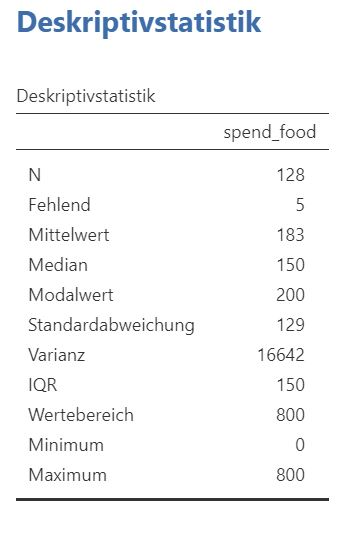

Kann auch nach einer Gruppenvariable (bspw. Geschlecht) aufgeteilt werden.

### 1.2 Graphiken

**Nominale und Ordinale Daten:** Häufigkeiten

`Analysen -> Exploration -> Deskriptivstatistik -> Diagramme -> Balkendiagramm`

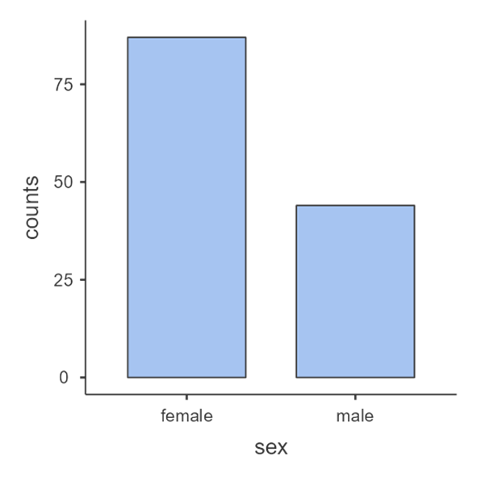

`Analysen -> Exploration -> Deskriptivstatistik -> Pareto-Diagramm`

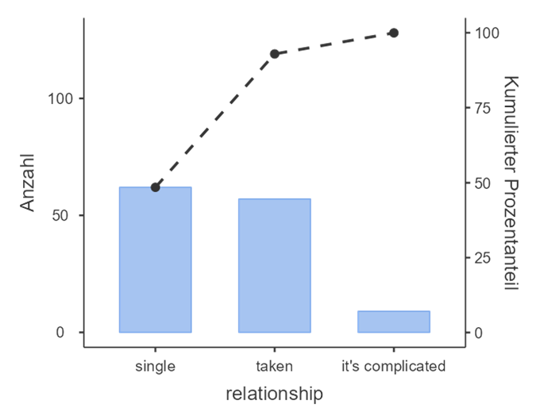

**Numerische Daten und Ordinale Daten:** Boxplot und Violinplot

`Analysen -> Exploration -> Deskriptivstatistik -> Diagramme -> Boxplots`

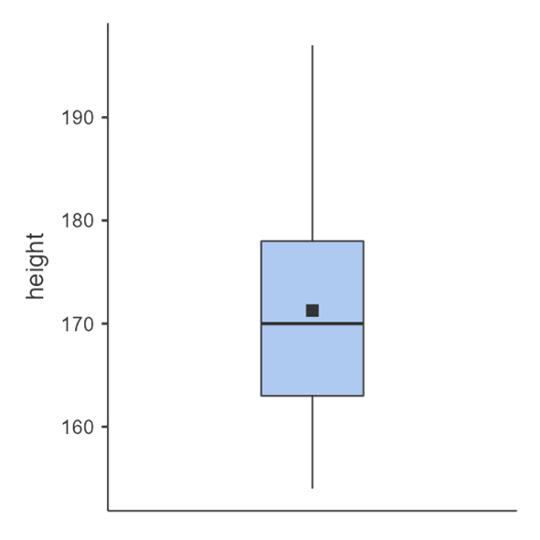

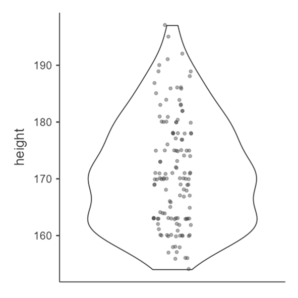

**Numerische Daten:** Histogramm und Dichte

`Analysen -> Exploration -> Deskriptivstatistik -> Diagramme -> Histogramme`

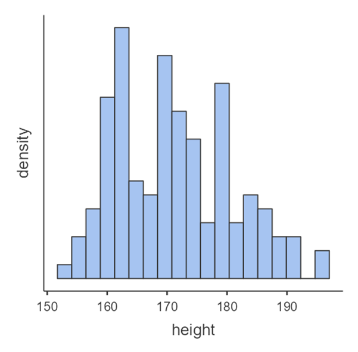

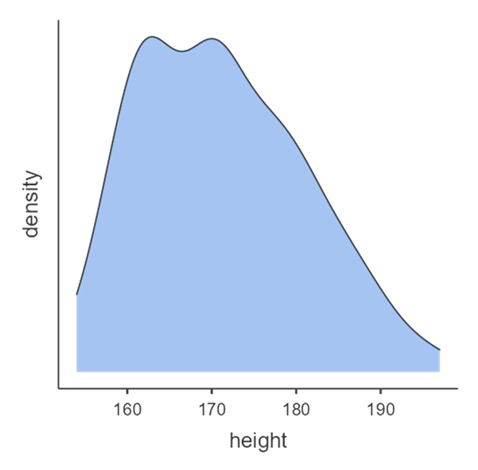

**Bivariate numerische Daten:** Streudiagramm

`Analysen -> Exploration -> Deskriptivstatistik -> Streudiagramm`

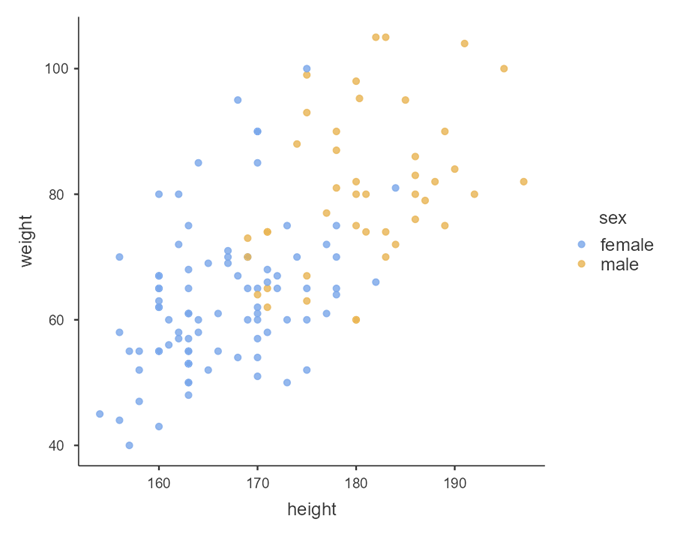

## 2 Testmethoden

### 2.1 Ablauf statistischer Test

1. **Problemstellung und Hypothesen formulieren**  
   Nullhypothese $H_0$ ("Status Quo") und Alternativhypothese $H_1$ ("Forschungshypothese")
2. **Passenden statistischen Test auswählen**
3. **Voraussetzungen des Tests prüfen**  
   bspw. Varianzhomogenität, Normalverteilung
4. **Ggf. Voranalyse**
5. **Ggf. Data Engineering**  
   bspw. Codierung
6. **Test durchführen und interpretieren**

### 2.2 Testen von Lageparametern

Übersicht:

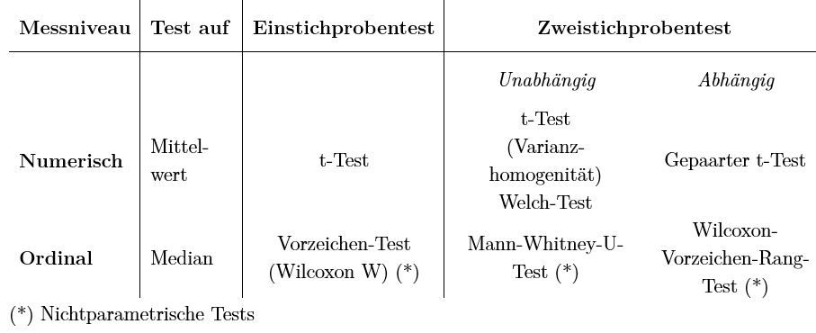

Beispiel: Zweistichproben t-Test (unabhängig)

**Schritt 1:** Problemstellung und Hypothesen formulieren
$$H_0: Durschnittsgröße Mann \le Durchschnittsgröße Frau$$ $$H_1: Durschnittsgröße Mann > Durchschnittsgröße Frau$$

**Schritt 2:** Passenden Test auswählen  
Unabhängiger Zweistichproben t-Test

**Schritt 3:** Voraussetzungen des Tests überprüfen

Voraussetzungen t-Test

- **T1. Numerische abhängige Variable.**
- **T2. Normalität.** Die Population(en) sind normalverteilt.
- **T3. Unabhängigkeit.** Die Messungen innerhalb und zwischen den Gruppen sind unabhängig.
- **T4. Binäre Gruppenvariable.** Es werden genau zwei Gruppen verglichen. [*]
- **T5. Homoskedastizität.** Varianzhomogenität: Varianz Gruppe 1 = Varianz Gruppe 2. [*]

[*] Nur für Zweistichprobentest

T1.  
Körpergröße ist numerisch. ✔

T2.  
Überprüfung: Shapiro-Wilk-Test ($H_0: \text{Normalverteilung}$, $H_1: \text{Keine Normalverteilung}$) und QQ-Plot:  
Erst nach Gruppe filtern, dann `Analysen -> Exploration -> Deskriptivstatistik -> Shapiro-Wilk und Q-Q`

Gruppe Männer:

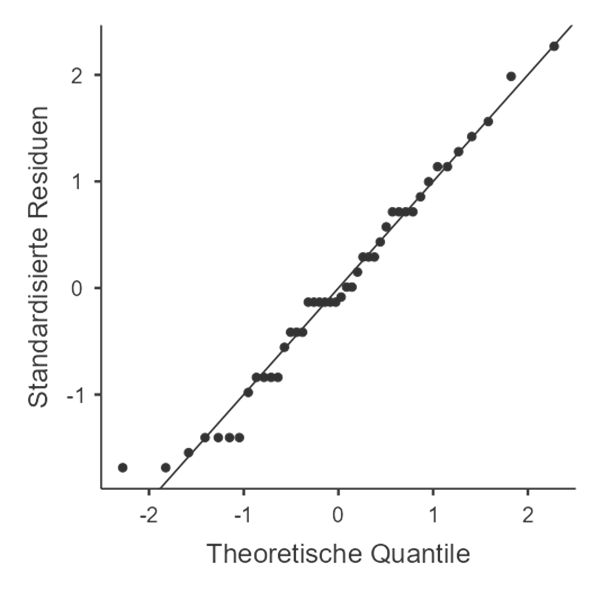

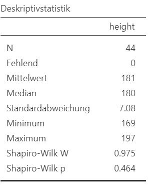

→ Erfüllt ✔

Gruppe Frauen:

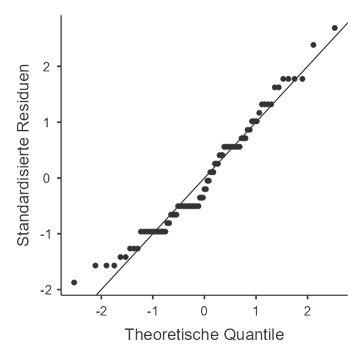

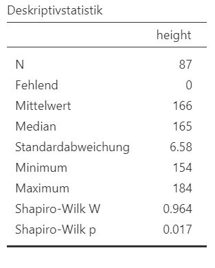

→ Nicht erfüllt ✘

T3.  
Messungen sind unabhängig. ✔

T4.  
Nur 2 Gruppen. ✔

T5.  
Überprüfung: Levenes Test ($H_0: \text{Varianzen aller Gruppen sind gleich}$, $H_1: \text{Varianzen mindestens zweier Gruppen unterscheiden sich}$)

`Analysen -> t-Test für unabhängige Stichproben -> Homogenitätstest`

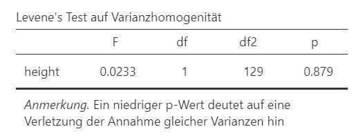

→ Erfüllt ✔

#### Was tun, wenn die Voraussetzungen des Tests verletzt sind?

Abhängig von der Art der Verletzung:

- Bei gewissen Verletzungen (bspw. abhängige Variable nicht-numerisch) kann der Test nicht durchgeführt werden
  - Bspw. bei ordinaler Variable Mann-Whitney-U-Test verwenden.

Bei anderen Verletzungen erhalten wir weniger robuste Resultate.

- Bei Verletzungen der Verteilungsannahme (Normalität), verwenden eines nichtparametrischen Tests zur Überprüfung der Resultate

**Schritt 4:** Voranalyse

`Analysen -> t-Test für unabhängige Stichproben -> Deskriptivstatistik und Deskriptive Diagramme`

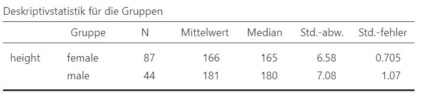

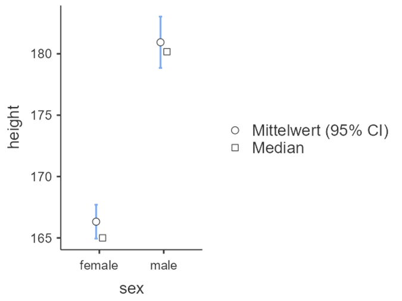

**Schritt 5:** Test durchführen und interpretieren

`Analysen -> t-Test für unabhängige Stichproben`

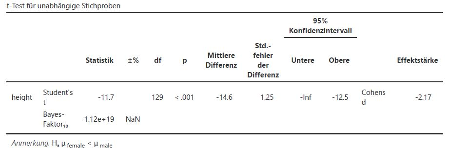

→ p-Wert < 5% → $H_0$ kann abgelehnt werden → Statistisch signifikant → Beleg für $H_1$

Effektstärke: $$Cohens \:d = \frac{Mittelwert_1 - Mittelwert_2}{gepoolte\: Standardabweichung}$$

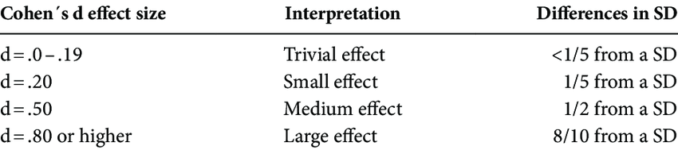

Bayes-Faktor: $$BF_{10}=\frac{P(\text{Beobachtete Daten | H1 wahr})}{P(\text{Beobachtete Daten | H0 wahr})}$$

### 2.3 Testen von Zusammenhängen

Übersicht:

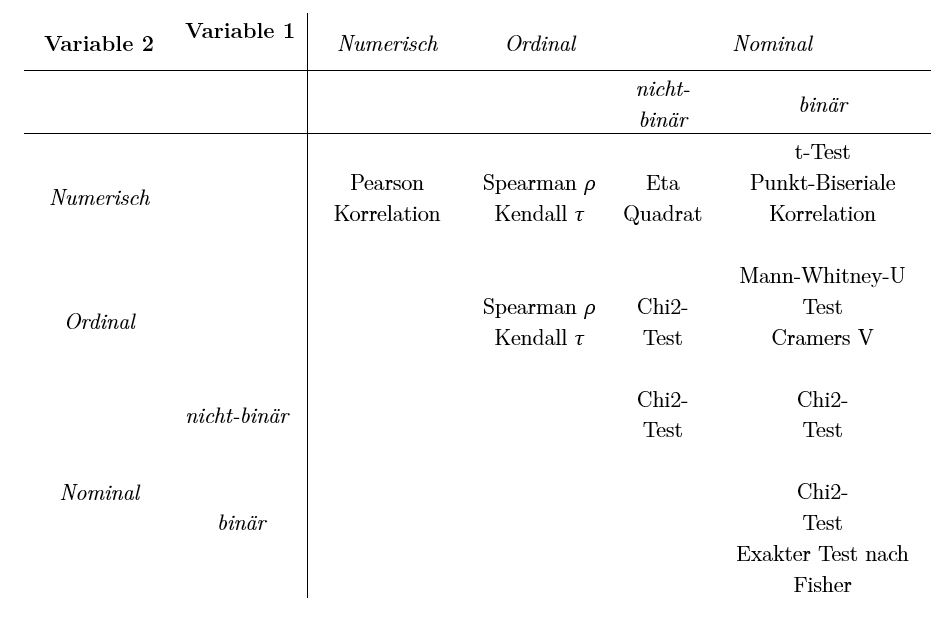

#### 2.3.1 Pearson Korrelationskoeffizient

Die Kovarianz misst die lineare Beziehung zwischen zwei Variablen X und Y:

$$cov(X,Y)=\frac{(x_1-Mittelwert_x)(y_1-Mittelwert_y)+...+(x_n-Mittelwert_x)(y_n-Mittelwert_y)}{n-1}$$

Da die Kovarianz von der Einheit der Messungen abhängt wird in der Praxis eine normierte Variante der Kovarianz verwendet - der *Pearson Korrelationskoeffizient r*:

$$r=\frac{cov(X,Y)}{Standardabweichung_X\cdot Standardabweichung_Y}$$

Der Pearson Korrelationskoeffizient kann nur Werte zwischen -1 und +1 annehmen, wobei -1 eine perfekte negative lineare Beziehung und +1 eine perfekte positive lineare Beziehung anzeigt:

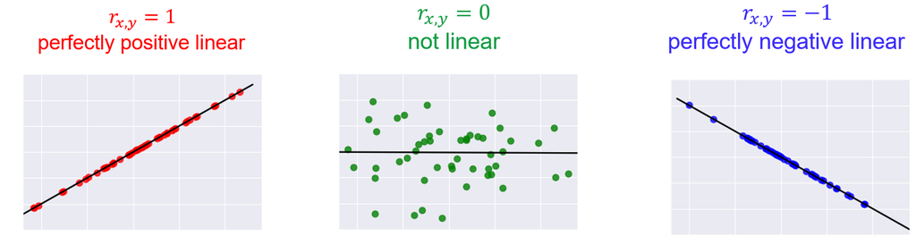

Beispiel: Korrelationstest mit Pearson Korrelationskoeffizient (Pearsons r)

**Schritt 1:** Problemstellung und Hypothesen formulieren  
Wir wollen wissen, ob Größe und Gewicht positiv korreliert sind. Wir müssen also testen, ob der Korrelationskoeffizient signifikant positiv ist.

$$H_0: r_{GrößeGewicht}\le 0$$ $$H_1: r_{GrößeGewicht}> 0$$

**Schritt 2:** Passenden Test auswählen  
Da Größe und Gewicht beide numerisch → Pearson Korrelationskoeffizient

**Schritt 3:** Voraussetzungen des Tests überprüfen

Vorraussetzungen Pearson Korrelationstest

- **PK1. Beide Variablen sind numerisch.**
- **PK2. Normalität.** Die Variablen sind normalverteilt.
- **PK3. Unabhängigkeit.** Die Messungen sind unabhängig.

Besprechung der Voraussetzungen → Vorlesung.

**Schritt 4:** Voranalyse

`Analysen -> Exploration -> Streudiagramm`

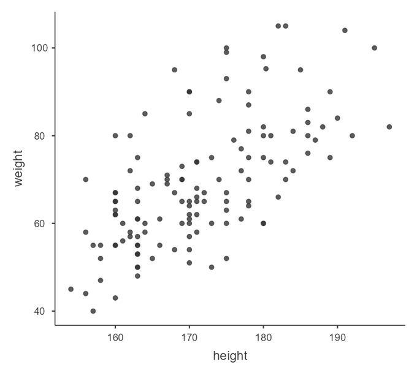

**Schritt 5:** Test durchführen und interpretieren

`Analysen -> Regression -> Korrelationsmatrix`

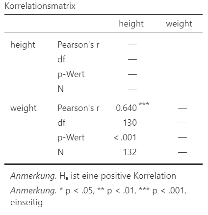

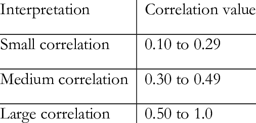

Außerdem ist $r^2=0,64^2=40,96\%$ der Anteil der Varianz, den die Variablen teilen und der somit erklärt wird.

#### 2.3.2 Spearman Rho und Kendall Tau Korrelationskoeffizient

Im Falle ordinaler Variablen können wir die Kovarianz nicht berechnen, da wir keinen Mittelwert berechnen können. Korrelationskoeffizienten werden mithilfe von *rangbasierten* Ansätzen bestimmt, die die Daten der Größe nach ordnen und jeder Beobachtung entsprechend ihrer Position einen Rang zuweisen. Beliebte rangbasierte Korrelationskoeffizienten sind: Spearmans Rho und Kendalls Tau.

Rangbasierte Ansätze identifizieren allgemeinere monotone Zusammenhänge:

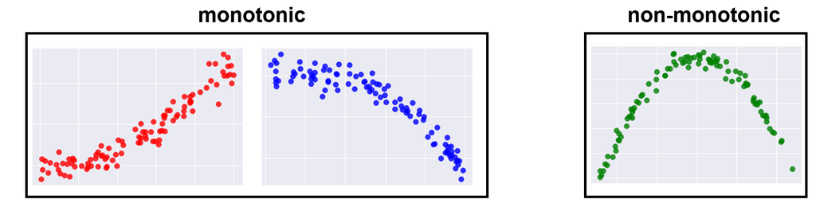

Ein Koeffizient von 1 zeigt eine perfekt positive monotone Beziehung an:

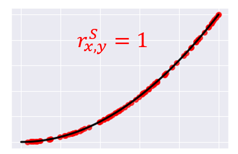

Voraussetzungen rangbasierte Korrelationstests

- **RK1. Ordinal.** Beide variablen sind mindestens ordinal.
- **RK2. Unabhängigkeit.** Die Messungen sind unabhängig.

Spearmans Rho:
Dieser Koeffizient funktioniert genauso wie Pearsons r, mit dem Unterschied, dass er die Kovarianz und die Standardabweichungen in Bezug auf die Ränge anstelle der Werte der Variablen berechnet. $$r^S=\frac{cov(Rang(X),Rang(Y))}{Standardabweichung_{Rang(X)}\cdot Standardabweichung_{Rang(Y)}}$$

Beziehung zwischen dem Spearman und Kendall Koeffizient: $$Kendall \approx 0.7\cdot Spearman$$

Ausführlichere Beispiele zu Spearman Rho und Kendall Tau → Vorlesung.

#### 2.3.3 Partielle Korrelation

Beim Testen von Korrelationen müssen wir potenzielle Störvariablen berücksichtigen. Angenommen, wir möchten testen, ob das Alter mit dem Kauf von Bio-Produkten korreliert. Dann müssen wir auch berücksichtigen, dass das Alter mit dem Einkommen korreliert, das wiederum mit dem Kauf der (teureren) Bio-Produkte korreliert sein könnte.

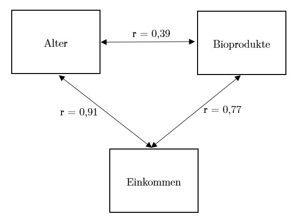

Die Korrelation von 0,39 könnte zum Teil auf die positive Korrelation zwischen Alter und Einkommen zurückzuführen sein. Daher müssen wir den Effekt des Einkommens eliminieren. Die partielle Korrelationsanalyse bietet eine Möglichkeit, dies zu tun.

Partieller Korrelationskoeffizient:
Seien X, Y und Z drei Variablen. Angenommen, wir möchten die Korrelation zwischen X und Y untersuchen, während wir für Z kontrollieren. Der angepasste Korrelationskoeffizient ist dann: $$r_{XY,Z}=\frac{r_{XY}-r_{XZ}\cdot r_{YZ}}{\sqrt{1-r_{XZ}^2}\cdot\sqrt{1-r_{YZ}^2}}$$

#### 2.3.4 Unabhängigkeitstests

Um zu testen, ob eine nominale und eine nominale oder ordinale Variable miteinander assoziiert sind, können wir einen Unabhängigkeitstest verwenden:

Chi2 ($\chi^2$) Test oder exakter Test nach Fisher (bei $2\times 2$ Kontingenztafeln)

Hypothesen: $$H_0: \text{Die Variablen X und Y sind unabhängig und } H_1: \text{Die Variablen X und Y sind abhängig.}$$

Beispiel: Unabhängigkeitstest

**Schritt 1:** Problemstellung und Hypothesen formulieren  
Wir wollen wissen, ob Haarfarbe und Augenfarbe voneinander abhängen.

$$H_0: \text{Haarfarbe und Augenfarbe sind unabhängig}$$ $$H_1: \text{Haarfarbe und Augenfarbe sind abhängig}$$

**Schritt 2:** Passenden Test auswählen  
Da Haarfarbe (black, blonde, brown, red) und Augenfarbe (blue, brown, green) zu einer $4\times 3$-Tafel führen → Chi2-Test

**Schritt 3:** Voraussetzungen des Tests überprüfen

Vorraussetzungen Chi2-Unabhängigkeitstest

- **C1. Beide Variablen sind kategorial.**
- **C2. Große Stichprobe.** Daumenregel: n > 50.
- **C3. Hinreichend große erwartete Häufigkeiten.** Alle erwarteten Häufigkeiten > 5.
- **C4. Unabhängigkeit.** Messungen sind unabhängig.

Besprechung der Voraussetzungen → Vorlesung.

**Schritt 4:** Voranalyse

`Analysen -> Häufigkeiten -> Unabhängige Stichproben -> Balkendiagramm`

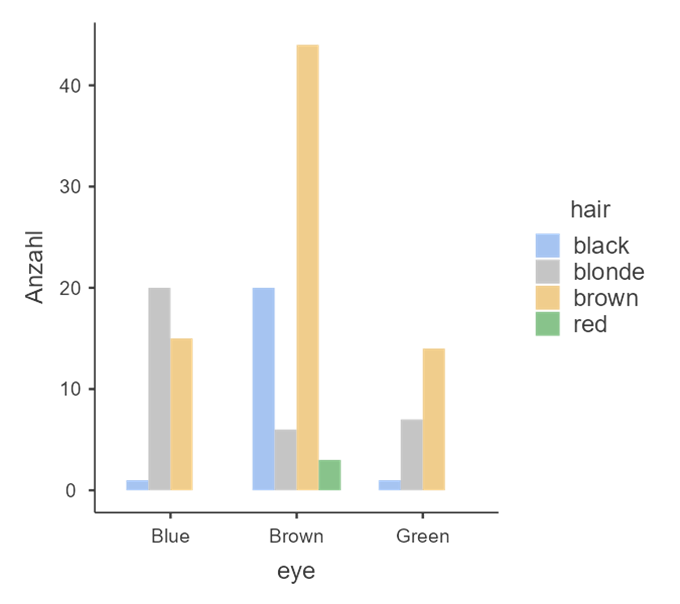

`Analysen -> Häufigkeiten -> Unabhängige Stichproben -> Anzahl Beobachtet / Erwartet`

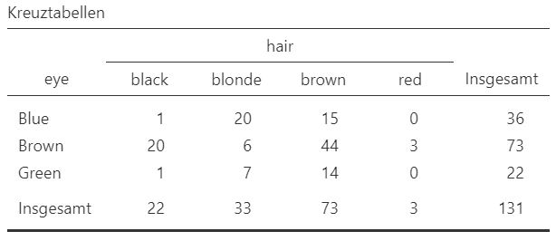

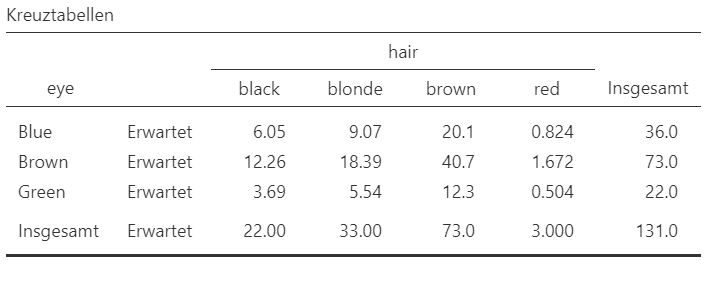

Wie berechnet man die erwarteten Häufigkeiten E?

$$E_{Zeile\:i,Spalte\:j}=\frac{(Beobachtet\: Zeile\: i)\times (Beobachtet\: Spalte\: j)}{Beobachtungen\:Gesamt}$$

Beispiel: $$E_{eye\:blue,hair\:black}=\frac{36\times 22}{131}\approx 6,05$$

Wie berechnet man die Chi2-Teststatistik?  
Allgemein für eine $n\times m$ Kontingenztafel mit B = beobachtete Häufigkeit und E = erwartete Häufigkeit:

$$\chi^2=\frac{(B_{1,1}-E_{1,1})^2}{E_{1,1}}+\dots+\frac{(B_{n,m}-E_{n,m})^2}{E_{n,m}}$$

Im Beispiel: $$\chi^2=\frac{(1-6,05)^2}{6,05}+\dots+\frac{(0-0,504)^2}{0,504}\approx 37,1$$

Wie bestimmt man die Freiheitsgrade eines Chi2-Tests?

$$Freiheitsgrade = (Anzahl Zeilen - 1)\times(Anzahl Spalten - 1)$$

Im Beispiel: $$Freiheitsgrade = 2\times 3=6$$

**Schritt 5:** Test durchführen und interpretieren

`Analysen -> Häufigkeiten -> Unabhängige Stichproben -> Tests Chi2`

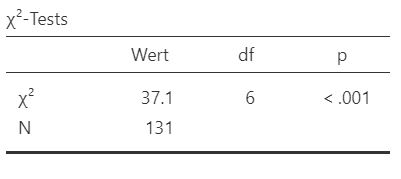

Effektstärke:  
`Analysen -> Häufigkeiten -> Unabhängige Stichproben -> Phi und Cramers V`

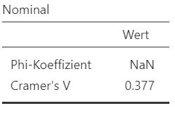

$$Cramers\: V = \sqrt{\frac{\chi^2/n}{min(Z-1,S-1)}},$$ wobei n = Stichprobengröße, Z = Anzahl Zeilen, S = Anzahl Spalten

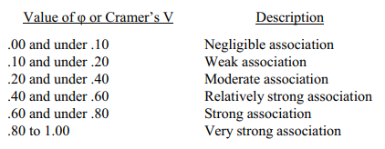

Quelle: Rea, L. M., and Parker, R. A. (1992). Designing and conducting survey research. San Francisco: Jossey-Boss.

**$2\times 2$-Kontingenztafel**

Wenn jede Variable 2 Kategorien hat, kann man entweder einen Chi2-Test mit Kontinuitätskorrektur oder einen exakten Test nach Fisher (Voraussetzungen siehe unten) durchführen:  
`Analysen -> Häufigkeiten -> Unabhängige Stichproben -> Tests`

Voraussetzungen exakter Test nach Fisher

- **E1. Binäre kategoriale Variablen.**
- **E2. Unabhängigkeit.**

Effektstärken bei $2\times 2$-Kontingengenztafeln  
`Analysen -> Häufigkeiten -> Unabhängige Stichproben -> Verglichene Maße`  
Gegeben folgende Kontingenztafel mit beobachteten Häufigkeiten a, b, c, d:

| a | b |
| --- | --- |
| c | d |

$$Odds-Ratio (OR)=\frac{a/b}{c/d}$$

$$Relatives Risiko (RR)=\frac{a/(a+b)}{c/(c+d)}$$

Interpretation → Vorlesung.

### 2.4 Multiples Testen

Problem: Multiple Tests führen zu einer Alphafehler-Inflation

Mögliche Korrekturen (p-Wert-Anpassungen) bei multiplen Tests:

**Bonferroni-Korrektur:**

$$p_{bonf}=p_{unangepasst}\times (\text{Anzahl Tests})$$

**Sidak-Korrektur:**

$$p_{sid}=1-(1-p_{unangepasst})^{(\text{Anzahl Tests})}$$

Beispiele → Vorlesung.

Die Anpassungen können von konservativ (lehnen die Nullhypothese seltener) ab nach liberal geordnet werden:

$$\text{konservativ -- Bonferroni -- Sidak -- Holm-Bonferroni -- Benjamini-Hochberg}$$